# Bayesian statisics with movie data

### Load packages

```r
library(ggplot2)
library(statsr)
library(BAS)
library(gridExtra)
library(reshape2)
library(PairedData)
library(tidyverse)
library(dplyr)
library(broom)
```

### Load data

```r
load("movies.Rdata")
```

## Introduction

This is a Data Analysis Project of the Bayesian Statistics course by Duke University (Coursera) The purpose of this project to learn what attributes make a movie popular. In this project Bayesian regression model will be developed to predict audience_score from the following explanatory variables.

| Variable | Description |
| --- | --- |
| genre: | Genre of movie (Action & Adventure, Comedy, Documentary, Drama, Horror, Mystery & Suspense, Other) |
| title | Title of movie |
| title_type | Type of movie (Documentary, Feature Film, TV Movie) |
| genre | Genre of movie (Action & Adventure, Comedy, Documentary, Drama, Horror, Mystery & Suspense, Other) |
| runtime | Runtime of movie (in minutes) |
| mpaa_rating | MPAA rating of the movie (G, PG, PG-13, R, Unrated) |
| studio | Studio that produced the movie |
| thtr_rel_year | Year the movie is released in theaters |
| thtr_rel_month | Month the movie is released in theaters |
| thtr_rel_day | Day of the month the movie is released in theaters |
| dvd_rel_year | Year the movie is released on DVD |
| dvd_rel_month | Month the movie is released on DVD |
| dvd_rel_day | Day of the month the movie is released on DVD |
| imdb_rating | Rating on IMDB |
| imdb_num_votes | Number of votes on IMDB |
| critics_rating | Categorical variable for critics rating on Rotten Tomatoes (Certified Fresh, Fresh, Rotten) |
| critics_score | Critics score on Rotten Tomatoes |
| audience_rating | Categorical variable for audience rating on Rotten Tomatoes (Spilled, Upright) |
| audience_score | Audience score on Rotten Tomatoes |
| best_pic_nom | Whether or not the movie was nominated for a best picture Oscar (no, yes) |
| best_pic_win | Whether or not the movie won a best picture Oscar (no, yes) |
| best_actor_win | Whether or not one of the main actors in the movie ever won an Oscar (no, yes) – note that this is not necessarily whether the actor won an Oscar for their role in the given movie |
| best_actress win | Whether or not one of the main actresses in the movie ever won an Oscar (no, yes) – not that this is not necessarily whether the actresses won an Oscar for their role in the given movie |
| best_dir_win | Whether or not the director of the movie ever won an Oscar (no, yes) – not that this is not necessarily whether the director won an Oscar for the given movie |
| top200_box | Whether or not the movie is in the Top 200 Box Office list on BoxOfficeMojo (no, yes) |
| director | Director of the movie |
| actor1 | First main actor/actress in the abridged cast of the movie |
| actor2 | Second main actor/actress in the abridged cast of the movie |
| actor3 | Third main actor/actress in the abridged cast of the movie |
| actor4 | Fourth main actor/actress in the abridged cast of the movie |
| actor5 | Fifth main actor/actress in the abridged cast of the movie |
| imdb_url | Link to IMDB page for the movie |
| rt_url | Link to Rotten Tomatoes page for the movie |

## Part 1: Data

The data set is comprised of 651 randomly sampled movies produced and released before 2016. We data set has 32 variables, some of these variables are only there for informational purposes and do not make any sense to include in a statistical analysis.

Data Source: [Rotten Tomatoes](https://www.rottentomatoes.com/) and [IMDB](https://www.imdb.com/) APIs.

Some of the sources possible biases include:

- The dataset is based on audience opinion on IMDB and Rotten Tomatoes, having mostly US users, thus international movies excluded from the set.
- As per IDBM it were created 9433 films in a period of 1970 - 2016. The sample size is less than 10% and may be too small to represent the population

As the data set is randomly samlped, we can assume the data it broadly generalizable. This is an observational study where data is collected in a way that does not directly interfere with how the data arise. In general, observational studies can provide evidence of a naturally occurring association between variables, but they cannot by themselves show a causal connection.

## Part 2: Data manipulation

Firstly, I need to construct new variables, which will be used in the project.

```r
summary(movies)
```

```
##     title                  title_type                 genre
##  Length:651         Documentary : 55   Drama             :305
##  Class :character   Feature Film:591   Comedy            : 87
##  Mode  :character   TV Movie    :  5   Action & Adventure: 65
##                                        Mystery & Suspense: 59
##                                        Documentary       : 52
##                                        Horror            : 23
##                                        (Other)           : 60
##     runtime       mpaa_rating                               studio
##  Min.   : 39.0   G      : 19   Paramount Pictures              : 37
##  1st Qu.: 92.0   NC-17  :  2   Warner Bros. Pictures           : 30
##  Median :103.0   PG     :118   Sony Pictures Home Entertainment: 27
##  Mean   :105.8   PG-13  :133   Universal Pictures              : 23
##  3rd Qu.:115.8   R      :329   Warner Home Video               : 19
##  Max.   :267.0   Unrated: 50   (Other)                         :507
##  NA's   :1                     NA's                            :  8
##  thtr_rel_year  thtr_rel_month   thtr_rel_day    dvd_rel_year
##  Min.   :1970   Min.   : 1.00   Min.   : 1.00   Min.   :1991
##  1st Qu.:1990   1st Qu.: 4.00   1st Qu.: 7.00   1st Qu.:2001
##  Median :2000   Median : 7.00   Median :15.00   Median :2004
##  Mean   :1998   Mean   : 6.74   Mean   :14.42   Mean   :2004
##  3rd Qu.:2007   3rd Qu.:10.00   3rd Qu.:21.00   3rd Qu.:2008
##  Max.   :2014   Max.   :12.00   Max.   :31.00   Max.   :2015
##                                                 NA's   :8
##  dvd_rel_month     dvd_rel_day     imdb_rating    imdb_num_votes
##  Min.   : 1.000   Min.   : 1.00   Min.   :1.900   Min.   :   180
##  1st Qu.: 3.000   1st Qu.: 7.00   1st Qu.:5.900   1st Qu.:  4546
##  Median : 6.000   Median :15.00   Median :6.600   Median : 15116
##  Mean   : 6.333   Mean   :15.01   Mean   :6.493   Mean   : 57533
##  3rd Qu.: 9.000   3rd Qu.:23.00   3rd Qu.:7.300   3rd Qu.: 58300
##  Max.   :12.000   Max.   :31.00   Max.   :9.000   Max.   :893008
##  NA's   :8        NA's   :8
##          critics_rating critics_score    audience_rating audience_score
##  Certified Fresh:135    Min.   :  1.00   Spilled:275     Min.   :11.00
##  Fresh          :209    1st Qu.: 33.00   Upright:376     1st Qu.:46.00
##  Rotten         :307    Median : 61.00                   Median :65.00
##                         Mean   : 57.69                   Mean   :62.36
##                         3rd Qu.: 83.00                   3rd Qu.:80.00
##                         Max.   :100.00                   Max.   :97.00
##
```

[output cut: 17 more lines]

```
##  Length:651         Length:651         Length:651
##  Class :character   Class :character   Class :character
##  Mode  :character   Mode  :character   Mode  :character
##
##
##
##
##    imdb_url            rt_url
##  Length:651         Length:651
##  Class :character   Class :character
##  Mode  :character   Mode  :character
##
##
##
##
```

```r
movies_new <- movies %>%
              filter(!is.na(runtime), !is.na(dvd_rel_year), !is.na(dvd_rel_month), !is.na(studio)) %>%
              mutate(feature_film   = ifelse(title_type == "Feature Film", "yes","no"),
                     drama          = ifelse(genre == "Drama", "yes","no"),
                     mpaa_rating_R  = ifelse(mpaa_rating == "R", "yes","no"),
                     oscar_season   = ifelse(thtr_rel_month %in% c(10, 11, 12), "yes","no"),
                     summer_season  = ifelse(thtr_rel_month %in% c(5, 6, 7, 8), "yes","no"))
```

## Part 3: Exploratory data analysis (EDA)

We will begin EDA with the audience_score variable since it will be the response variable in the model.

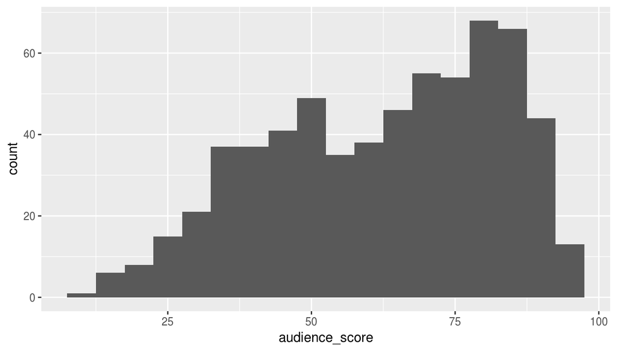

```r
ggplot(data = movies_new, aes(x = audience_score)) +
  geom_histogram(binwidth = 5)
```

```r
summary(movies_new$audience_score)
```

```
##    Min. 1st Qu.  Median    Mean 3rd Qu.    Max.
##   11.00   46.00   65.00   62.59   80.00   97.00
```

Let’s explore new variables to check the relationship between them and the audience score.

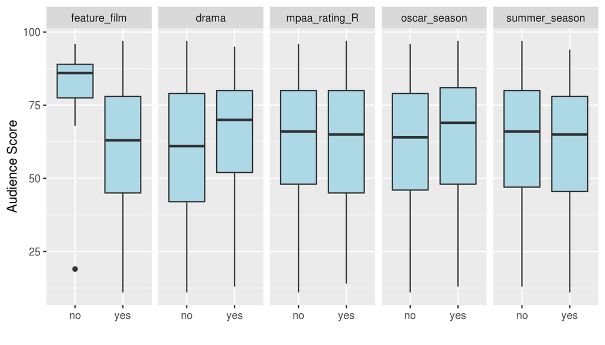

```r
dplyr::select(movies_new, audience_score, feature_film, drama, mpaa_rating_R, oscar_season, summer_season) %>%
  melt(measure.vars = 2:6) %>%
  ggplot(aes(x  = value, y = audience_score, fill = variable)) +
  geom_boxplot(fill="lightblue") +
  labs(x = "", y = "Audience Score") +
  facet_grid(.~variable)
```

```r
dplyr::select(movies_new, audience_score, feature_film, drama, mpaa_rating_R, oscar_season, summer_season) %>%
  melt(measure.vars = 2:6) %>%
  group_by(variable,value) %>%
  summarise(avg_audience_score = mean(audience_score), count = n())
```

```
## # A tibble: 10 x 4
## # Groups:   variable [?]
##    variable      value avg_audience_score count
##    <fct>         <chr>              <dbl> <int>
##  1 feature_film  no                  82.1    55
##  2 feature_film  yes                 60.7   579
##  3 drama         no                  60.0   333
##  4 drama         yes                 65.4   301
##  5 mpaa_rating_R no                  62.7   312
##  6 mpaa_rating_R yes                 62.4   322
##  7 oscar_season  no                  61.9   449
##  8 oscar_season  yes                 64.3   185
##  9 summer_season no                  62.9   431
## 10 summer_season yes                 61.9   203
```

# Feature Film

Most of variables except Feature Film and Drama have similar average audience score. We need to explore futher these variables.

The **feature_film** varibale was build based on the title_type variable, so we will perform EDA based on this variable.

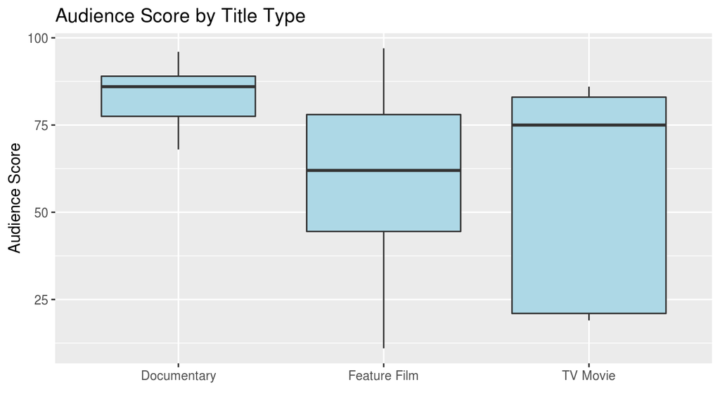

```r
ggplot(movies, aes(x=factor(title_type), y=audience_score)) +
  geom_boxplot(fill="lightblue") +
  labs(x = "", y = "Audience Score", title = "Audience Score by Title Type")
```

```r
movies %>%
  group_by(title_type) %>%
  summarise(count = n(), avg_audience_score = mean(audience_score), median_audience_score = median(audience_score),
            min_audience_score = min(audience_score), max_audience_score = max(audience_score))
```

```
## # A tibble: 3 x 6
##   title_type count avg_audience_sc… median_audience… min_audience_sc…
##   <fct>      <int>            <dbl>            <dbl>            <dbl>
## 1 Documenta…    55             83.3               86               68
## 2 Feature F…   591             60.5               62               11
## 3 TV Movie       5             56.8               75               19
## # ... with 1 more variable: max_audience_score <dbl>
```

It looks like average audience score of the Feature Films is 60.47, but Documentary films are scored much higher (83.25). In the same time we have only 5 TV Movies, which is not sufficient enough for the data analysis.

Next we will conduct *a hypothesis test whether there is a difference between Feature and Non-Feature films.*

$$H_1 = H_2$$
$$H_1 \ne H_2$$

```r
statsr::bayes_inference(y = audience_score, x = feature_film,
                data = movies_new, statistic = "mean",
                type = "ht",null=0, alternative = "twosided")
```

```
## Response variable: numerical, Explanatory variable: categorical (2 levels)
## n_no = 55, y_bar_no = 82.1455, s_no = 11.3601
## n_yes = 579, y_bar_yes = 60.734, s_yes = 19.8036
## (Assuming Zellner-Siow Cauchy prior on the difference of means. )
## (Assuming independent Jeffreys prior on the overall mean and variance. )
## Hypotheses:
## H1: mu_no  = mu_yes
## H2: mu_no != mu_yes
##
## Priors: P(H1) = 0.5  P(H2) = 0.5
##
## Results:
## BF[H2:H1] = 422564181790
## P(H1|data) = 0
## P(H2|data) = 1
##
## Posterior summaries for under H2:
## Response variable: numerical, Explanatory variable: categorical (2 levels)
## n_no = 55, y_bar_no = 82.1455, s_no = 11.3601
## n_yes = 579, y_bar_yes = 60.734, s_yes = 19.8036
## (Assuming Zellner-Siow Cauchy prior for difference in means)
## (Assuming independent Jeffrey's priors for overall mean and variance)
##
##
## Posterior Summaries
##                       2.5%         25%        50%        75%       97.5%
## overall mean    68.5998705  70.3745762  71.304526  72.222217   73.932853
## mu_no - mu_yes  15.6832156  19.2596303  21.060665  22.883511   26.430757
## sigma^2        332.2696641 356.4111943 370.073584 384.056851  414.344582
## effect size      0.8097581   0.9986127   1.094725   1.193003    1.382498
## n_0             13.7558041 167.0440127 396.054207 797.451979 2153.959249
## 95% Cred. Int.: (15.6832 , 26.4308)
```

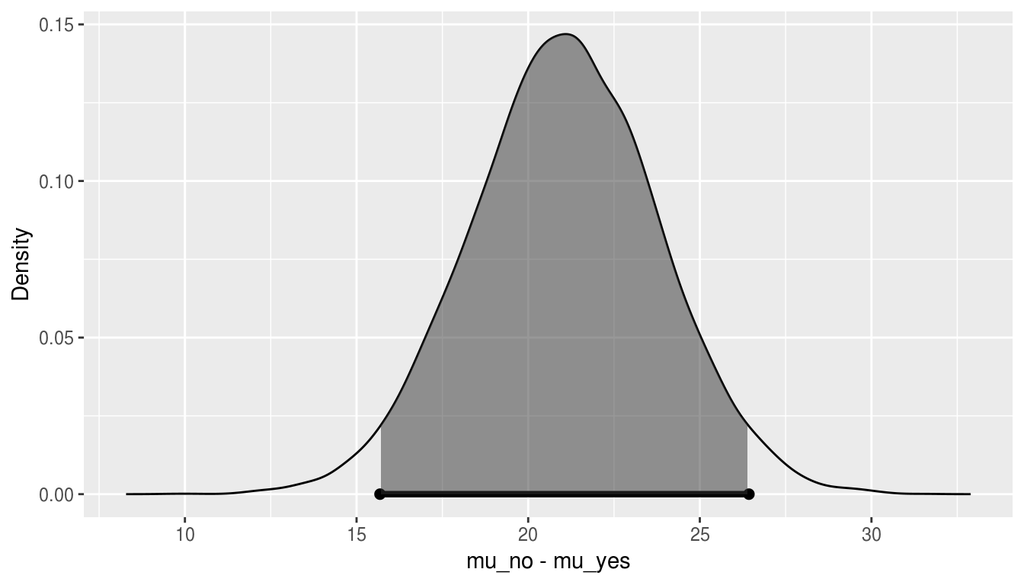

The result showing is that there is very strong evidence against H1, which means that there is a significant difference of mean audience score between Feature and Non-Feature films.

# Drama

The **drama** variable was build based on genre variable, which we will explore below.

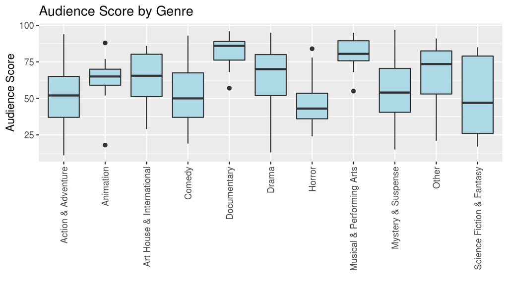

```r
ggplot(movies, aes(x=factor(genre), y=audience_score)) +
  geom_boxplot(fill="lightblue") +
  labs(x = "", y = "Audience Score", title = "Audience Score by Genre") +
  theme(axis.text.x = element_text(angle = 90, vjust = 0.5, hjust=1))
```

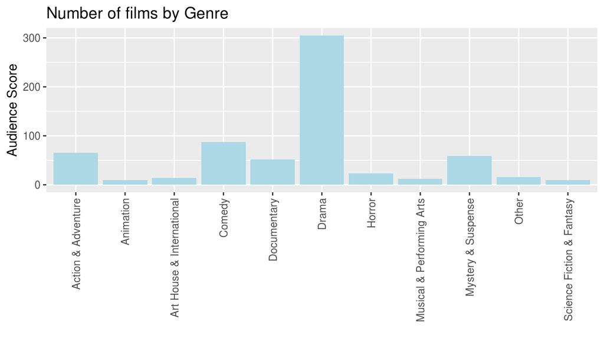

```r
ggplot(movies, aes(x=factor(genre))) +
  geom_bar(fill="lightblue") +
  labs(x = "", y = "Audience Score", title = "Number of films by Genre") +
  theme(axis.text.x = element_text(angle = 90, vjust = 0.5, hjust=1))
```

```r
movies %>%
  group_by(genre) %>%
  summarise(count = n(), avg_audience_score = mean(audience_score), median_audience_score = median(audience_score))
```

```
## # A tibble: 11 x 4
##    genre                     count avg_audience_score median_audience_score
##    <fct>                     <int>              <dbl>                 <dbl>
##  1 Action & Adventure           65               53.8                  52
##  2 Animation                     9               62.4                  65
##  3 Art House & International    14               64                    65.5
##  4 Comedy                       87               52.5                  50
##  5 Documentary                  52               82.8                  86
##  6 Drama                       305               65.3                  70
##  7 Horror                       23               45.8                  43
##  8 Musical & Performing Arts    12               80.2                  80.5
##  9 Mystery & Suspense           59               55.9                  54
## 10 Other                        16               66.7                  73.5
## 11 Science Fiction & Fantasy     9               50.9                  47
```

Next we will conduct a hypothesis test whether there is a difference between Drama and Non-Drama films.

$$H_1 = H_2$$
$$H_1 \ne H_2$$

```r
statsr::bayes_inference(y = audience_score, x = drama,
                data = movies_new, statistic = "mean",
                type = "ht",null=0, alternative = "twosided")
```

```
## Response variable: numerical, Explanatory variable: categorical (2 levels)
## n_no = 333, y_bar_no = 60.009, s_no = 21.1218
## n_yes = 301, y_bar_yes = 65.4485, s_yes = 18.6086
## (Assuming Zellner-Siow Cauchy prior on the difference of means. )
## (Assuming independent Jeffreys prior on the overall mean and variance. )
## Hypotheses:
## H1: mu_no  = mu_yes
## H2: mu_no != mu_yes
##
## Priors: P(H1) = 0.5  P(H2) = 0.5
##
## Results:
## BF[H2:H1] = 19.8439
## P(H1|data) = 0.048
## P(H2|data) = 0.952
##
## Posterior summaries for under H2:
## Response variable: numerical, Explanatory variable: categorical (2 levels)
## n_no = 333, y_bar_no = 60.009, s_no = 21.1218
## n_yes = 301, y_bar_yes = 65.4485, s_yes = 18.6086
## (Assuming Zellner-Siow Cauchy prior for difference in means)
## (Assuming independent Jeffrey's priors for overall mean and variance)
##
##
## Posterior Summaries
##                       2.5%         25%         50%          75%
## overall mean    61.1761106  62.1888978  62.7332410   63.2720311
## mu_no - mu_yes  -8.4967407  -6.4473006  -5.3404602   -4.2747074
## sigma^2        358.2983509 383.8543089 398.7858546  414.3840629
## effect size     -0.4256314  -0.3228801  -0.2670795   -0.2136127
## n_0             32.1852333 345.4426534 812.7654733 1651.0707983
##                       97.5%
## overall mean     64.3223421
## mu_no - mu_yes   -2.1844520
## sigma^2         447.0197988
## effect size      -0.1091226
## n_0            4348.9043315
## 95% Cred. Int.: (-8.4967 , -2.1845)
```

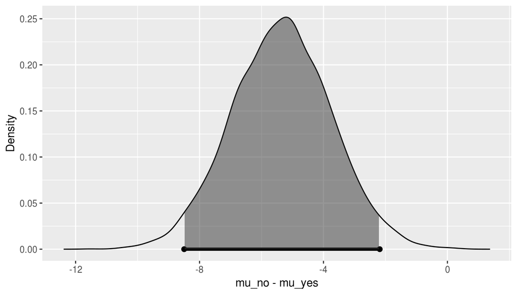

The result is showing that there is strong evidence against H1, which means that there is a significant difference of mean audience score between Drama and Non-Drama films.

# MPAA Rating

Audience score distribution between **mpaa-ratings** are the same. The hypothesis test shows a positive evidence against H2, which means there is no significant difference of mean audience score between mpaa-raings.

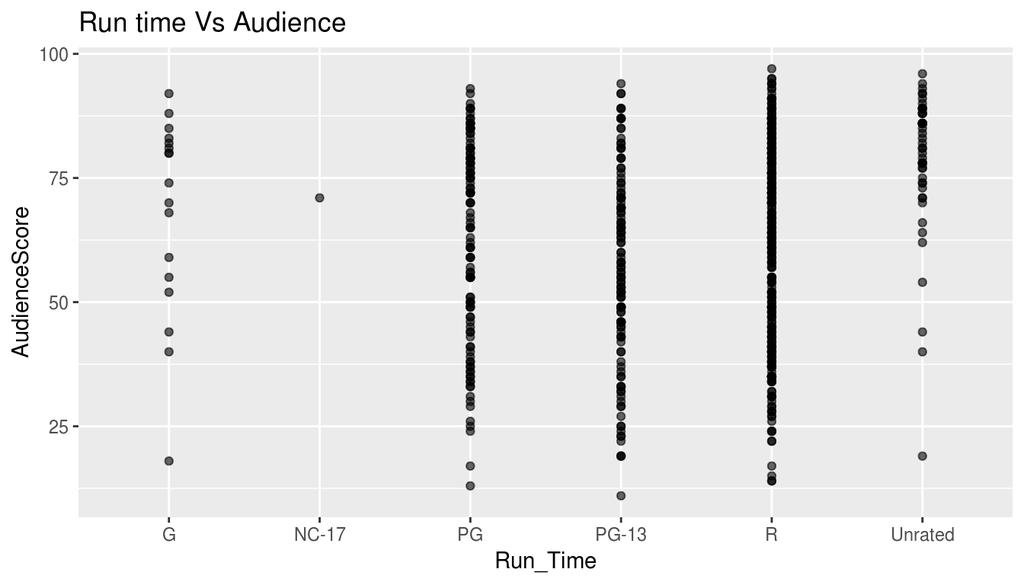

```r
ggplot(movies_new, aes(mpaa_rating, audience_score)) +
  geom_point(alpha = 0.6) +
  xlab("Run_Time") +
  ylab("AudienceScore") +
  ggtitle("Run time Vs Audience") +
  stat_smooth(method = "lm", se = FALSE)
```

```r
statsr::bayes_inference(y = audience_score, x = mpaa_rating_R,
                data = movies_new, statistic = "mean",
                type = "ht",null=0, alternative = "twosided")
```

```
## Response variable: numerical, Explanatory variable: categorical (2 levels)
## n_no = 312, y_bar_no = 62.7436, s_no = 20.2802
## n_yes = 322, y_bar_yes = 62.4441, s_yes = 20.0275
## (Assuming Zellner-Siow Cauchy prior on the difference of means. )
## (Assuming independent Jeffreys prior on the overall mean and variance. )
## Hypotheses:
## H1: mu_no  = mu_yes
## H2: mu_no != mu_yes
##
## Priors: P(H1) = 0.5  P(H2) = 0.5
##
## Results:
## BF[H1:H2] = 15.6027
## P(H1|data) = 0.9398
## P(H2|data) = 0.0602
##
## Posterior summaries for under H2:
## Response variable: numerical, Explanatory variable: categorical (2 levels)
## n_no = 312, y_bar_no = 62.7436, s_no = 20.2802
## n_yes = 322, y_bar_yes = 62.4441, s_yes = 20.0275
## (Assuming Zellner-Siow Cauchy prior for difference in means)
## (Assuming independent Jeffrey's priors for overall mean and variance)
##
##
## Posterior Summaries
##                       2.5%         25%          50%          75%
## overall mean    60.9862410  62.0644894  62.58540475 6.314084e+01
## mu_no - mu_yes  -2.8214879  -0.7731088   0.30411748 1.389513e+00
## sigma^2        363.9097761 390.2345462 405.55010047 4.215292e+02
## effect size     -0.1398192  -0.0386784   0.01510526 6.904847e-02
## n_0             29.7987425 359.0109258 847.17886752 1.694445e+03
##                       97.5%
## overall mean     64.1474086
## mu_no - mu_yes    3.3715944
## sigma^2         453.9818440
## effect size       0.1686033
## n_0            4679.8151657
## 95% Cred. Int.: (-2.8215 , 3.3716)
```

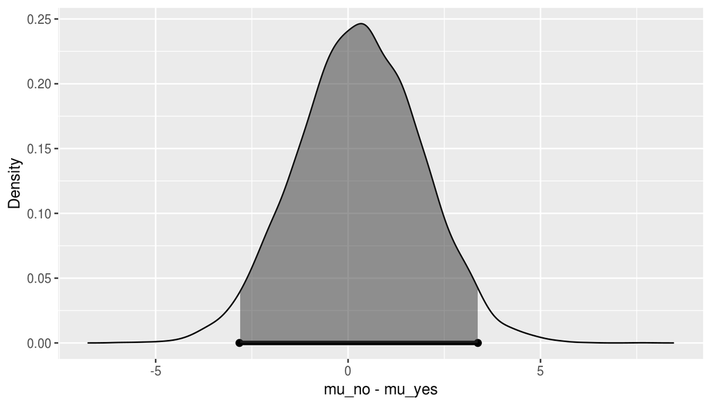

# Oscar / Summer Season

Audience score distribution between **thtr_rel_month** are prety the same. The hypothesis test conducted on **oscar_season** and **summer_season** variables represent a positive evidence against H2, which means there is no significant difference of mean audience score between Oscar vs non Oscar ,and summer and non-summer seasons.

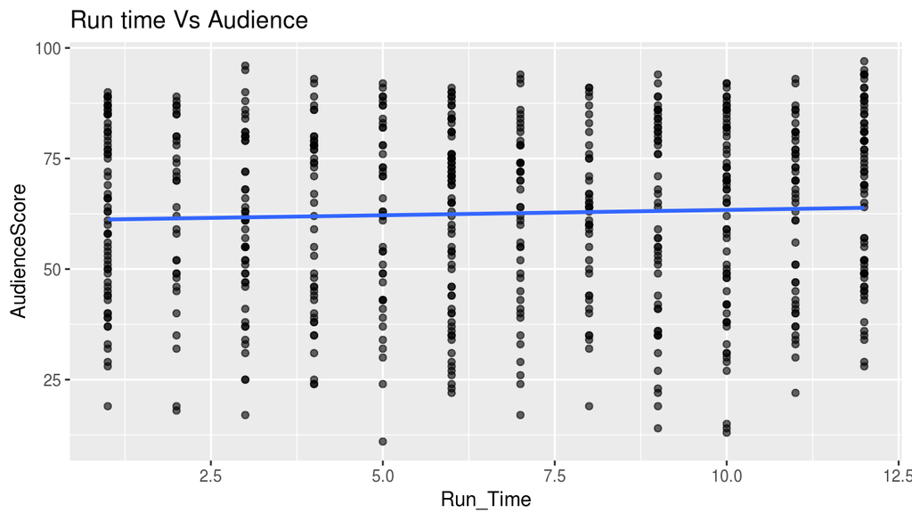

```r
ggplot(movies_new, aes(thtr_rel_month, audience_score)) +
  geom_point(alpha = 0.6) +
  xlab("Run_Time") +
  ylab("AudienceScore") +
  ggtitle("Run time Vs Audience") +
  stat_smooth(method = "lm", se = FALSE)
```

```r
statsr::bayes_inference(y = audience_score, x = oscar_season,
                data = movies_new, statistic = "mean",
                type = "ht",null=0, alternative = "twosided")
```

```
## Response variable: numerical, Explanatory variable: categorical (2 levels)
## n_no = 449, y_bar_no = 61.9042, s_no = 20.0972
## n_yes = 185, y_bar_yes = 64.2595, s_yes = 20.1898
## (Assuming Zellner-Siow Cauchy prior on the difference of means. )
## (Assuming independent Jeffreys prior on the overall mean and variance. )
## Hypotheses:
## H1: mu_no  = mu_yes
## H2: mu_no != mu_yes
##
## Priors: P(H1) = 0.5  P(H2) = 0.5
##
## Results:
## BF[H1:H2] = 5.9695
## P(H1|data) = 0.8565
## P(H2|data) = 0.1435
##
## Posterior summaries for under H2:
## Response variable: numerical, Explanatory variable: categorical (2 levels)
## n_no = 449, y_bar_no = 61.9042, s_no = 20.0972
## n_yes = 185, y_bar_yes = 64.2595, s_yes = 20.1898
## (Assuming Zellner-Siow Cauchy prior for difference in means)
## (Assuming independent Jeffrey's priors for overall mean and variance)
##
##
## Posterior Summaries
##                       2.5%        25%         50%           75%
## overall mean    61.3423728  62.503750  63.0867433   63.68236732
## mu_no - mu_yes  -5.7251854  -3.507316  -2.3211326   -1.16845132
## sigma^2        363.2146316 389.875848 404.7772944  420.51065410
## effect size     -0.2839749  -0.174376  -0.1153991   -0.05834643
## n_0             27.5809548 355.876365 863.5602046 1725.37516536
##                       97.5%
## overall mean   6.483033e+01
## mu_no - mu_yes 1.108824e+00
## sigma^2        4.526959e+02
## effect size    5.491629e-02
## n_0            4.670085e+03
## 95% Cred. Int.: (-5.7252 , 1.1088)
```

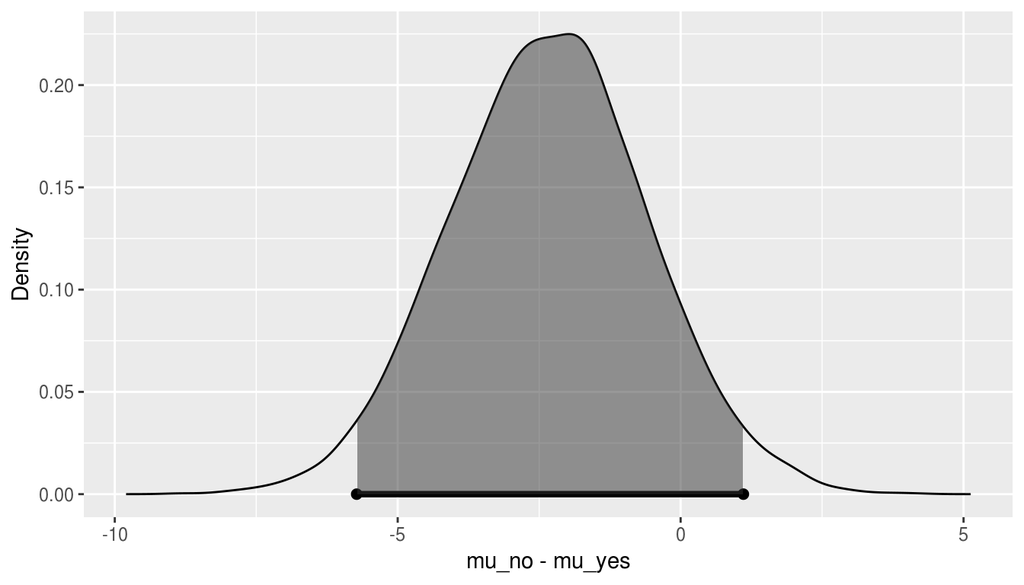

```r
statsr::bayes_inference(y = audience_score, x = summer_season,
                data = movies_new, statistic = "mean",
                type = "ht",null=0, alternative = "twosided")
```

```
## Response variable: numerical, Explanatory variable: categorical (2 levels)
## n_no = 431, y_bar_no = 62.9072, s_no = 20.2977
## n_yes = 203, y_bar_yes = 61.9212, s_yes = 19.8241
## (Assuming Zellner-Siow Cauchy prior on the difference of means. )
## (Assuming independent Jeffreys prior on the overall mean and variance. )
## Hypotheses:
## H1: mu_no  = mu_yes
## H2: mu_no != mu_yes
##
## Priors: P(H1) = 0.5  P(H2) = 0.5
##
## Results:
## BF[H1:H2] = 12.596
## P(H1|data) = 0.9264
## P(H2|data) = 0.0736
##
## Posterior summaries for under H2:
## Response variable: numerical, Explanatory variable: categorical (2 levels)
## n_no = 431, y_bar_no = 62.9072, s_no = 20.2977
## n_yes = 203, y_bar_yes = 61.9212, s_yes = 19.8241
## (Assuming Zellner-Siow Cauchy prior for difference in means)
## (Assuming independent Jeffrey's priors for overall mean and variance)
##
##
## Posterior Summaries
##                       2.5%          25%          50%          75%
## overall mean    60.7430575  61.86320164  62.44013827   63.0257675
## mu_no - mu_yes  -2.3197287  -0.23695617   0.92104757    2.1043665
## sigma^2        364.2632617 390.47534679 405.09392035  421.0247602
## effect size     -0.1147095  -0.01178399   0.04580532    0.1042937
## n_0             31.8239322 361.55877036 885.67135412 1739.9600938
##                       97.5%
## overall mean     64.1166203
## mu_no - mu_yes    4.3070469
## sigma^2         454.5321396
## effect size       0.2129589
## n_0            4645.4015349
## 95% Cred. Int.: (-2.3197 , 4.307)
```

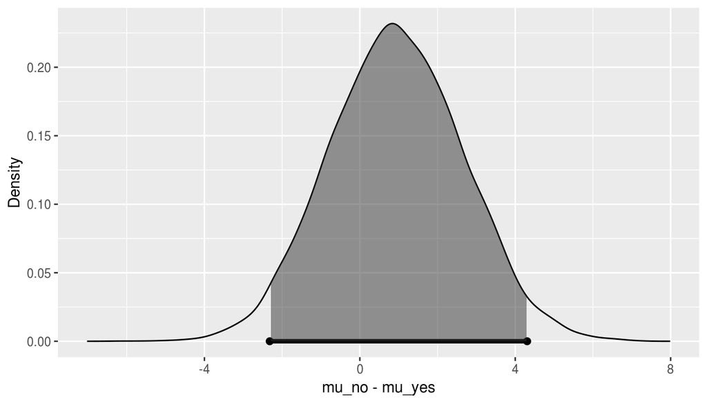

Only 2 of the new constructed variables will be used for the modeling: **feature_film and drama** , which have significant evidence of being influenced to the audience score.

## Part 4: Modeling

In this chapter I will conduct the modeling for the audience score. Firstly, I select only variables I will use for the modeling:

```r
df_model <- dplyr::select(movies_new, audience_score, feature_film, drama,
                runtime, thtr_rel_year, imdb_rating, imdb_num_votes,
                critics_score, best_pic_nom, best_pic_win, best_actor_win,
                best_actress_win, best_dir_win, top200_box)
```

The full liniar model have many coefficients of independent variables are not statistically significant.

```r
m_model_full <- lm(audience_score ~ . - audience_score, data = na.omit(df_model))

tidy(m_model_full)
```

```
## # A tibble: 14 x 5
##    term                     estimate   std.error statistic  p.value
##    <chr>                       <dbl>       <dbl>     <dbl>    <dbl>
##  1 (Intercept)          131.         80.6            1.63  1.04e- 1
##  2 feature_filmyes       -2.21        1.73          -1.27  2.04e- 1
##  3 dramayes               1.09        0.882          1.24  2.15e- 1
##  4 runtime               -0.0601      0.0242        -2.48  1.34e- 2
##  5 thtr_rel_year         -0.0797      0.0398        -2.00  4.59e- 2
##  6 imdb_rating           14.6         0.622         23.4   2.25e-87
##  7 imdb_num_votes         0.00000698  0.00000457     1.53  1.27e- 1
##  8 critics_score          0.0646      0.0224         2.88  4.11e- 3
##  9 best_pic_nomyes        5.01        2.62           1.91  5.65e- 2
## 10 best_pic_winyes       -2.95        4.63          -0.638 5.24e- 1
## 11 best_actor_winyes     -1.55        1.19          -1.30  1.93e- 1
## 12 best_actress_winyes   -2.15        1.31          -1.64  1.01e- 1
## 13 best_dir_winyes       -1.39        1.74          -0.801 4.23e- 1
## 14 top200_boxyes          1.31        2.78           0.472 6.37e- 1
```

As the purpose of this project is to build a predictive model, I will use a least restricted AIC method. With AIC some non-informative variables could be included in the model for better prediciton.

```r
model_aic = bas.lm(audience_score ~ . -audience_score, data = df_model,
                   prior = "AIC", modelprior = uniform())

round(summary(model_aic),2)
```

```
##                     P(B != 0 | Y)  model 1  model 2  model 3  model 4
## Intercept                    1.00     1.00     1.00     1.00     1.00
## feature_filmyes              0.35     0.00     0.00     0.00     0.00
## dramayes                     0.35     0.00     0.00     0.00     0.00
## runtime                      0.88     1.00     1.00     1.00     1.00
## thtr_rel_year                0.58     1.00     0.00     1.00     0.00
## imdb_rating                  1.00     1.00     1.00     1.00     1.00
## imdb_num_votes               0.44     0.00     0.00     0.00     0.00
## critics_score                0.98     1.00     1.00     1.00     1.00
## best_pic_nomyes              0.66     1.00     1.00     1.00     1.00
## best_pic_winyes              0.30     0.00     0.00     0.00     0.00
## best_actor_winyes            0.49     0.00     0.00     1.00     1.00
## best_actress_winyes          0.58     1.00     1.00     1.00     1.00
## best_dir_winyes              0.38     0.00     0.00     0.00     0.00
## top200_boxyes                0.32     0.00     0.00     0.00     0.00
## BF                             NA     1.00     0.95     0.95     0.86
## PostProbs                      NA     0.01     0.01     0.01     0.01
## R2                             NA     0.75     0.75     0.75     0.75
## dim                            NA     7.00     6.00     8.00     7.00
## logmarg                        NA -3510.85 -3510.90 -3510.90 -3511.00
##                      model 5
## Intercept               1.00
## feature_filmyes         0.00
## dramayes                0.00
## runtime                 1.00
## thtr_rel_year           1.00
## imdb_rating             1.00
## imdb_num_votes          1.00
## critics_score           1.00
## best_pic_nomyes         1.00
## best_pic_winyes         0.00
## best_actor_winyes       0.00
## best_actress_winyes     1.00
## best_dir_winyes         0.00
## top200_boxyes           0.00
## BF                      0.75
## PostProbs               0.01
## R2                      0.75
## dim                     8.00
## logmarg             -3511.14
```

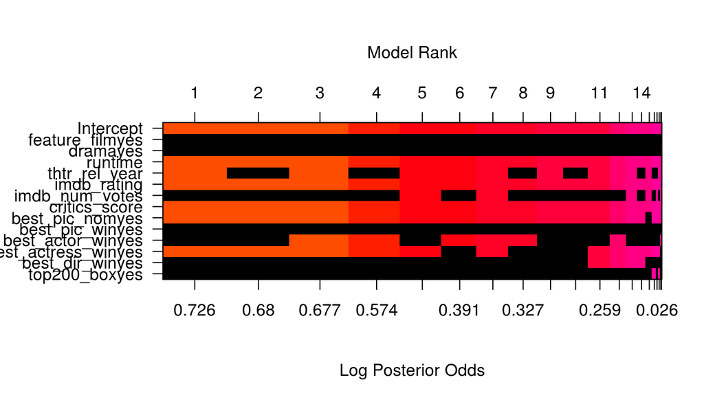

```r
image(model_aic, rotate=FALSE, intensity=TRUE)
```

As you can see runtime, imdb_rating, critics_score, best_pic_nom variables exists in most of the models.

```r
confint(coef(model_aic))
```

```
##                              2.5%        97.5%          beta
## Intercept            6.181349e+01 6.335289e+01  6.259148e+01
## feature_filmyes     -3.624076e+00 1.227313e+00 -4.843457e-01
## dramayes            -4.562270e-01 2.112562e+00  2.477888e-01
## runtime             -9.686958e-02 0.000000e+00 -5.122110e-02
## thtr_rel_year       -1.292591e-01 3.784890e-03 -3.642520e-02
## imdb_rating          1.355729e+01 1.603272e+01  1.481328e+01
## imdb_num_votes      -1.960108e-06 1.198257e-05  2.315135e-06
## critics_score        2.321911e-02 1.171279e-01  6.910036e-02
## best_pic_nomyes      0.000000e+00 8.754520e+00  2.964050e+00
## best_pic_winyes     -7.948808e+00 5.048664e+00 -5.002806e-01
## best_actor_winyes   -3.732354e+00 1.668014e-01 -8.154126e-01
## best_actress_winyes -4.328690e+00 8.980560e-02 -1.216290e+00
## best_dir_winyes     -4.172237e+00 9.499066e-01 -6.180697e-01
## top200_boxyes       -1.994761e+00 5.794094e+00  5.795125e-01
## attr(,"Probability")
## [1] 0.95
## attr(,"class")
## [1] "confint.bas"
```

```r
coef(model_aic)
```

```
##
##  Marginal Posterior Summaries of Coefficients:
##
##  Using  BMA
##
##  Based on the top  8192 models
##                      post mean   post SD     post p(B != 0)
## Intercept             6.259e+01   3.994e-01   1.000e+00
## feature_filmyes      -4.843e-01   1.213e+00   3.484e-01
## dramayes              2.478e-01   6.166e-01   3.464e-01
## runtime              -5.122e-02   2.929e-02   8.819e-01
## thtr_rel_year        -3.643e-02   4.313e-02   5.798e-01
## imdb_rating           1.481e+01   6.376e-01   1.000e+00
## imdb_num_votes        2.315e-06   3.951e-06   4.415e-01
## critics_score         6.910e-02   2.398e-02   9.821e-01
## best_pic_nomyes       2.964e+00   2.930e+00   6.622e-01
## best_pic_winyes      -5.003e-01   2.688e+00   2.993e-01
## best_actor_winyes    -8.154e-01   1.181e+00   4.935e-01
## best_actress_winyes  -1.216e+00   1.446e+00   5.764e-01
## best_dir_winyes      -6.181e-01   1.313e+00   3.751e-01
## top200_boxyes         5.795e-01   1.771e+00   3.188e-01
```

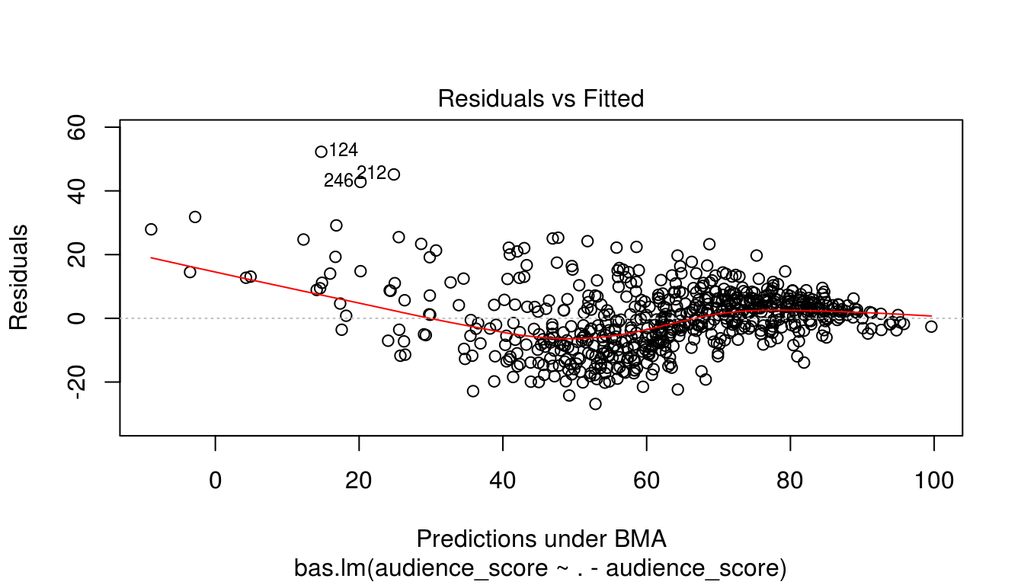

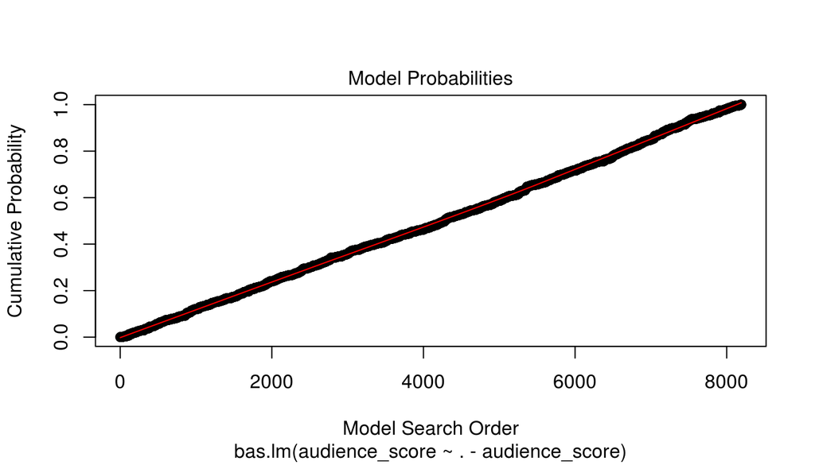

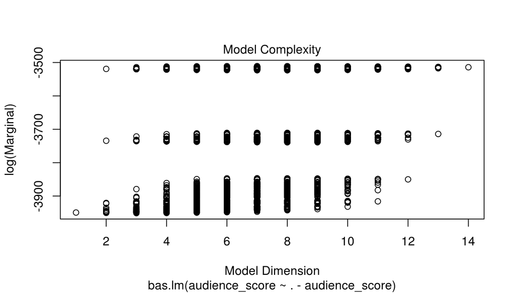

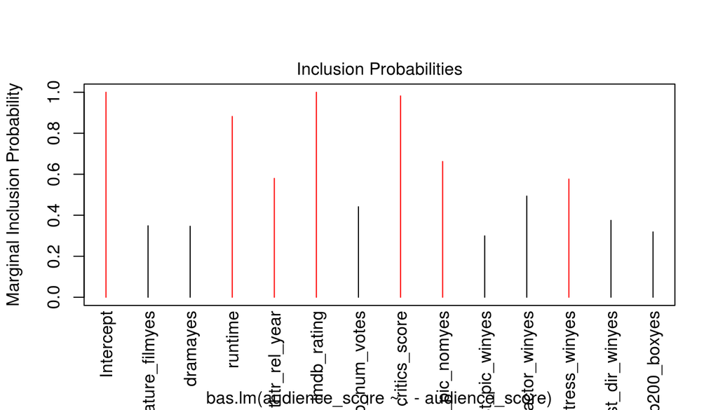

```r
plot(model_aic, ask=F)
```

According to diagnostic there are a few outliers at rows 124, 246, and 212. Additionally the residual plot doesn’t look quite random. There are many positive residuals for the lower predicted scores. Hence movies with low scores aren’t quite as low as we are predicting.

The model completity appears to peak around the 5 to 9 mark which makes sense given that we have 6 variables in our model.

## Part 5: Prediction

To test a model I chose 3 films.

**Arrival**

https://www.imdb.com/title/tt2543164/

https://www.rottentomatoes.com/m/arrival_2016

```r
movie_p <- data.frame(runtime = 116,
                      thtr_rel_year = 2016,
                      feature_film = 'yes',
                      drama = 'yes',
                      imdb_rating = 7.9,
                      critics_score = 94,
                      imdb_num_votes = 488604,
                      best_pic_win = 'no',
                      best_pic_nom = 'no',
                      best_actor_win = 'no',
                      best_actress_win = 'no',
                      best_dir_win = 'no',
                      top200_box = 'no')

prediction_Revenant <- predict(model_aic, newdata=movie_p, estimator="BPM")
prediction_Revenant$Ybma
```

```
##          [,1]
## [1,] 85.80941
```

The predicted audience score 85.8 is fairly close to the actual rating 82.

**La La Land**

https://www.imdb.com/title/tt3783958/

https://www.rottentomatoes.com/m/la_la_land

```r
movie_p <- data.frame(runtime = 128,
                      thtr_rel_year = 2016,
                      feature_film = 'yes',
                      drama = 'yes',
                      imdb_rating = 8,
                      critics_score = 81,
                      imdb_num_votes = 412821,
                      best_pic_win = 'no',
                      best_pic_nom = 'yes',
                      best_actor_win = 'no',
                      best_actress_win = 'yes',
                      best_dir_win = 'yes',
                      top200_box = 'no')

prediction_Revenant <- predict(model_aic, newdata=movie_p, estimator="BPM")
prediction_Revenant$Ybma
```

```
##          [,1]
## [1,] 86.73202
```

The predicted audience score 86.7 is fairly close to the actual rating 81.

**Norm of the North**

https://www.imdb.com/title/tt1594972/?ref_=ttls_li_tt

https://www.rottentomatoes.com/m/norm_of_the_north

```r
movie_p <- data.frame(runtime = 90,
                      thtr_rel_year = 2016,
                      feature_film = 'yes',
                      drama = 'yes',
                      imdb_rating = 3.6,
                      critics_score = 9,
                      imdb_num_votes = 7743,
                      best_pic_win = 'no',
                      best_pic_nom = 'no',
                      best_actor_win = 'no',
                      best_actress_win = 'no',
                      best_dir_win = 'no',
                      top200_box = 'no')

prediction_Revenant <- predict(model_aic, newdata=movie_p, estimator="BPM")
prediction_Revenant$Ybma
```

```
##          [,1]
## [1,] 16.45726
```

The predicted audience score 16.5 is fairly close to the actual rating 22.

## Part 6: Conclusion

The predictive model satisfies the expectation even though the diagnostics were not very good. Some limitations of this work consisted on the very small sample population.

At the same time, predicting of Rotten Tomatoes audience score based on IMDB Rating seems quite useless due to the fact that the same audience evaluate films on both web-sites. However, I gained good knowledge of Bayesian statiscs while doing the project.